# Population_PK_Modeling_Simulation

Amaka

2026-11-03

# 1. Project Overview

This project demonstrates exploratory pharmacokinetic data analysis using R.

The dataset contains simulated one-compartment intravenous bolus pharmacokinetic data.

The objectives are to examine the dataset structure, identify dosing and observation records, visualize individual concentration-time profiles, and characterize population pharmacokinetic variability.

# 2. Import Pharmacokinetic Dataset

```r
dim(pk_data)
```

```
## [1] 7920   14
```

```r
names(pk_data)
```

```
##  [1] "ID"   "TIME" "DV"   "LNDV" "MDV"  "AMT"  "EVID" "DOSE" "V"    "CL"
## [11] "SS"   "II"   "SD"   "CMT"
```

```r
kable(
  head(pk_data),
  caption = "First six records of the PK dataset"
)
```

First six records of the PK dataset

| ID | TIME | DV | LNDV | MDV | AMT | EVID | DOSE | V | CL | SS | II | SD | CMT |
| --- | --- | --- | --- | --- | --- | --- | --- | --- | --- | --- | --- | --- | --- |
| 1 | 0.00 | 0.0 | 0.0000 | 1 | 60000 | 1 | 60000 | 65.14 | 4.07 | 99 | 0 | 1 | 1 |
| 1 | 0.25 | 1126.1 | 7.0265 | 0 | 0 | 0 | 60000 | 65.14 | 4.07 | 99 | 0 | 1 | 1 |
| 1 | 0.50 | 869.9 | 6.7683 | 0 | 0 | 0 | 60000 | 65.14 | 4.07 | 99 | 0 | 1 | 1 |
| 1 | 0.75 | 883.6 | 6.7840 | 0 | 0 | 0 | 60000 | 65.14 | 4.07 | 99 | 0 | 1 | 1 |
| 1 | 1.00 | 1244.0 | 7.1260 | 0 | 0 | 0 | 60000 | 65.14 | 4.07 | 99 | 0 | 1 | 1 |
| 1 | 1.50 | 995.2 | 6.9029 | 0 | 0 | 0 | 60000 | 65.14 | 4.07 | 99 | 0 | 1 | 1 |

# 3. Dataset Summary

```r
observations <- pk_data %>%
  filter(EVID == 0, MDV == 0)

dataset_summary <- data.frame(
  Subjects = n_distinct(pk_data$ID),
  Records = nrow(pk_data),
  Variables = ncol(pk_data),
  Observations = nrow(observations),
  Missing_Values = sum(is.na(pk_data))
)

kable(
  dataset_summary,
  caption = "Summary of PK dataset"
)
```

Summary of PK dataset

| Subjects | Records | Variables | Observations | Missing_Values |
| --- | --- | --- | --- | --- |
| 120 | 7920 | 14 | 6951 | 0 |

```r
write_csv(
  dataset_summary,
  "results/tables/Dataset_Summary.csv"
)
```

# 4. Dosing and Observation Records

```r
event_summary <- pk_data %>%
  count(EVID, MDV, name = "Records")

kable(
  event_summary,
  caption = "Distribution of dosing and observation records"
)
```

Distribution of dosing and observation records

| EVID | MDV | Records |
| --- | --- | --- |
| 0 | 0 | 6951 |
| 1 | 1 | 960 |
| 2 | 1 | 9 |

```r
write_csv(
  event_summary,
  "results/tables/Event_Summary.csv"
)
```

```r
# 3.1 Descriptive Statistics of the PK Dataset

#This section summarizes the distribution of pharmacokinetic
#variables, including sampling time, observed concentrations,
#clearance, and volume of distribution.

# Select relevant PK variables
pk_descriptive <- pk_data %>%
  select(TIME, DV, DOSE, CL, V)

# Generate descriptive statistics
descriptive_summary <- data.frame(
  Parameter = names(pk_descriptive),
  Minimum = sapply(pk_descriptive, min, na.rm = TRUE),
  Q1 = sapply(pk_descriptive, quantile, probs = 0.25, na.rm = TRUE),
  Median = sapply(pk_descriptive, median, na.rm = TRUE),
  Mean = sapply(pk_descriptive, mean, na.rm = TRUE),
  Q3 = sapply(pk_descriptive, quantile, probs = 0.75, na.rm = TRUE),
  Maximum = sapply(pk_descriptive, max, na.rm = TRUE)
)

# Display formatted summary
knitr::kable(
  descriptive_summary,
  digits = 2,
  row.names = FALSE,
  caption = "Descriptive Statistics of PK Variables"
)
```

Descriptive Statistics of PK Variables

| Parameter | Minimum | Q1 | Median | Mean | Q3 | Maximum |
| --- | --- | --- | --- | --- | --- | --- |
| TIME | 0.00 | 36.00 | 146.25 | 132.98 | 216.75 | 288.00 |
| DV | 0.00 | 63.18 | 266.60 | 542.59 | 752.65 | 4410.20 |
| DOSE | 10000.00 | 25000.00 | 45000.00 | 55000.00 | 75000.00 | 120000.00 |
| CL | 1.92 | 3.39 | 3.96 | 4.13 | 4.81 | 8.11 |
| V | 30.35 | 55.70 | 66.24 | 72.09 | 85.32 | 136.00 |

```r
# Save summary for GitHub
write.csv(
  descriptive_summary,
  "results/tables/Descriptive_PK_Statistics.csv",
  row.names = FALSE
)
```

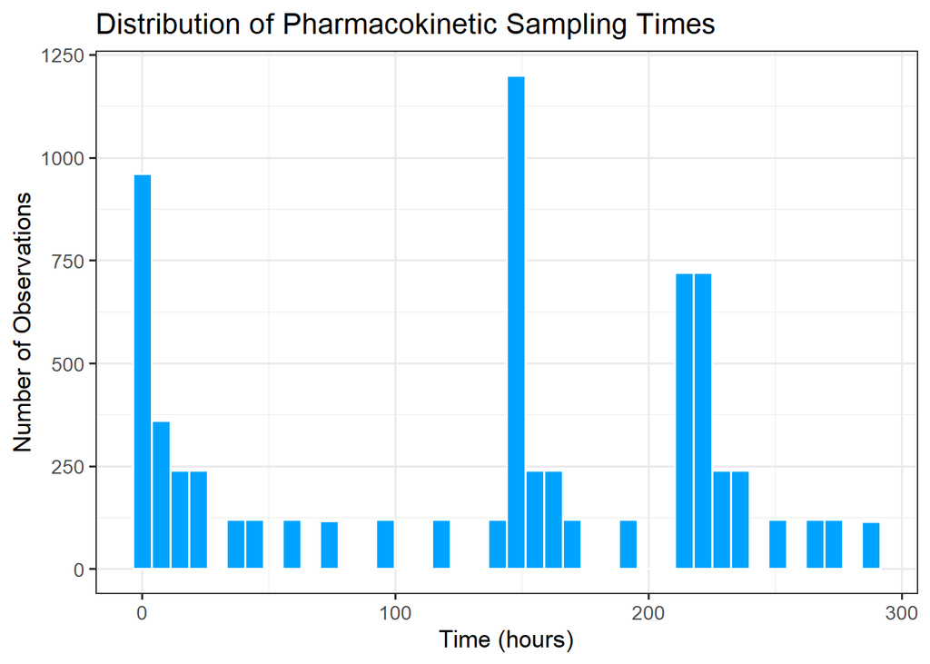

```r
# 4. Pharmacokinetic Sampling Time Distribution

#The distribution of sampling times was examined to characterize the temporal coverage of pharmacokinetic observations.

# Select observation records
observations <- pk_data %>%
  filter(EVID == 0, MDV == 0)

# Plot sampling time distribution
p_sampling <- ggplot(
  observations,
  aes(x = TIME)
) +
  geom_histogram(
    bins = 40,
    fill = "#00A3FF",
    color = "white"
  ) +
  labs(
    title = "Distribution of Pharmacokinetic Sampling Times",
    x = "Time (hours)",
    y = "Number of Observations"
  ) +
  theme_bw(base_size = 13)

print(p_sampling)
```

```r
# Save figure
ggsave(
  "results/figures/Sampling_Time_Distribution.png",
  plot = p_sampling,
  width = 9,
  height = 6,
  dpi = 300
)
```

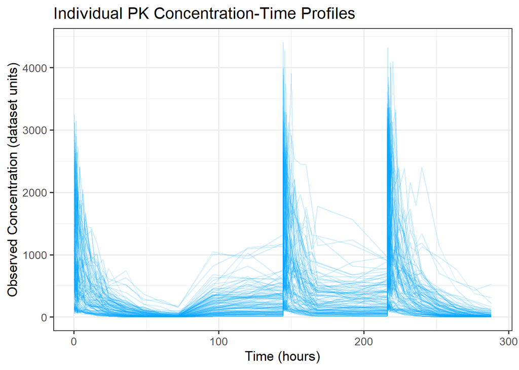

```r
# 5. Population Pharmacokinetic Visualization

#This analysis evaluates interindividual variability
#in observed drug concentration-time profiles.

# Extract observation records
observations <- pk_data %>%
  filter(EVID == 0, MDV == 0)

# Individual concentration-time profiles
p_individual <- ggplot(
  observations,
  aes(x = TIME, y = DV, group = ID)
) +
  geom_line(
    color = "#00A3FF",
    alpha = 0.20,
    linewidth = 0.4
  ) +
  labs(
    title = "Individual PK Concentration-Time Profiles",
    x = "Time (hours)",
    y = "Observed Concentration (dataset units)"
  ) +
  theme_bw(base_size = 13)

print(p_individual)
```

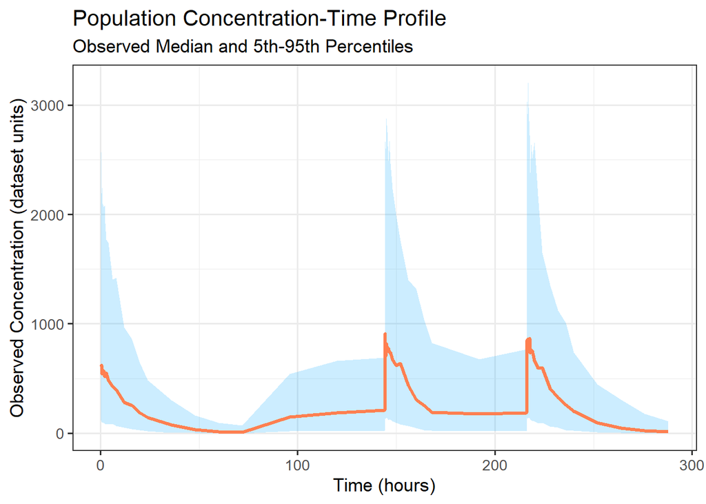

```r
ggsave(
  "results/figures/Individual_PK_Profiles.png",
  p_individual,
  width = 9,
  height = 6,
  dpi = 300
)

# Population concentration summary
# Summarize concentrations at observed sampling times
population_summary <- observations %>%
  group_by(TIME) %>%
  summarise(
    N = n(),
    Median = median(DV),
    P05 = quantile(DV, 0.05),
    P95 = quantile(DV, 0.95),
    .groups = "drop"
  )

# Restrict percentile ribbons to sampling times
# with at least 5 observations
population_plot_data <- population_summary %>%
  filter(N >= 5)

# Population median and percentile interval
p_population <- ggplot(
  population_plot_data,
  aes(x = TIME)
) +
  geom_ribbon(
    aes(ymin = P05, ymax = P95),
    fill = "#00A3FF",
    alpha = 0.20
  ) +
  geom_line(
    aes(y = Median),
    color = "#FF7F50",
    linewidth = 1.1
  ) +
  labs(
    title = "Population Concentration-Time Profile",
    subtitle = "Observed Median and 5th-95th Percentiles",
    x = "Time (hours)",
    y = "Observed Concentration (dataset units)"
  ) +
  theme_bw(base_size = 13)

print(p_population)
```

```r
ggsave(
  "results/figures/Population_PK_Profile.png",
  p_population,
  width = 9,
  height = 6,
  dpi = 300
)

# Save population summary
write.csv(
  population_summary,
  "results/tables/Population_PK_Summary.csv",
  row.names = FALSE
)
```

## Population Pharmacokinetic Profiles Across Sampling Windows

### Objective

To visualize observed concentration–time profiles and interindividual variability across three major sampling periods in a simulated repeated-dose intravenous bolus pharmacokinetic dataset.

Population medians and empirical 5th–95th percentiles were calculated using 4-hour time bins. Each subject contributed at most one median concentration per bin.

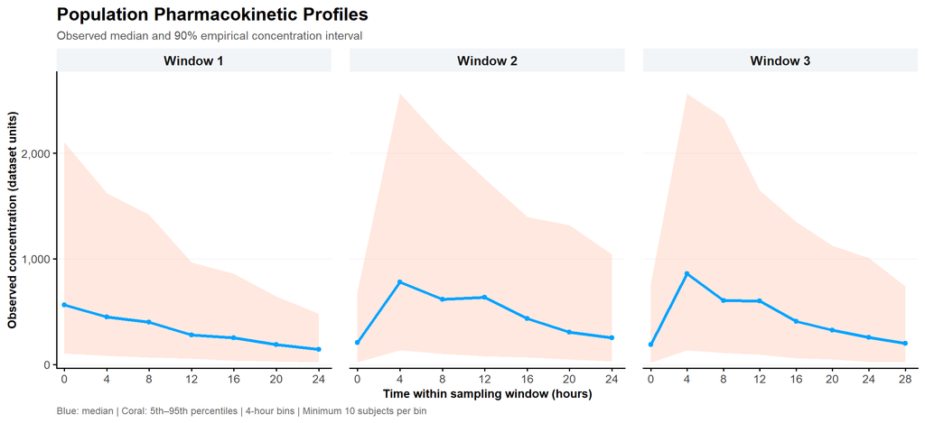

```r
library(dplyr)
library(ggplot2)
library(scales)

# ============================================================
# POPULATION PK: THREE SAMPLING WINDOWS
# ============================================================

# 1. Filter valid observations
pk_obs <- pk_data %>%
  filter(
    EVID == 0,
    MDV == 0,
    is.finite(DV),
    DV > 0,
    is.finite(TIME),
    TIME >= 0
  )

# 2. Define major sampling windows
# Windows based on the observed concentration-time plot
windows <- data.frame(
  Window = c("Window 1", "Window 2", "Window 3"),
  Start = c(0, 140, 212),
  End = c(24, 164, 240)
)

# 3. Assign observations to sampling windows
pk_window <- bind_rows(
  lapply(seq_len(nrow(windows)), function(i) {
    pk_obs %>%
      filter(
        TIME >= windows$Start[i],
        TIME <= windows$End[i]
      ) %>%
      mutate(
        Window = windows$Window[i],
        Relative_Time = TIME - windows$Start[i]
      )
  })
)

# 4. Create 4-hour bins within each window
bin_width <- 4

pk_window <- pk_window %>%
  mutate(
    Time_Bin = floor(Relative_Time / bin_width) *
      bin_width
  )

# 5. One concentration per subject per bin
subject_bin <- pk_window %>%
  group_by(Window, ID, Time_Bin) %>%
  summarise(
    Concentration = median(DV),
    .groups = "drop"
  )

# 6. Population summary
population_window_summary <- subject_bin %>%
  group_by(Window, Time_Bin) %>%
  summarise(
    N = n(),
    Median = median(Concentration),
    P05 = quantile(Concentration, 0.05),
    P95 = quantile(Concentration, 0.95),
    .groups = "drop"
  ) %>%
  filter(N >= 10) %>%
  mutate(
    Window = factor(
      Window,
      levels = windows$Window
    )
  )

# 7. Confirm sufficient data
if (nrow(population_window_summary) == 0) {
  stop("No time bins have at least 10 subjects.")
}

# 8. Generate professional three-panel figure
p_pk <- ggplot(
  population_window_summary,
  aes(x = Time_Bin)
) +
  geom_ribbon(
    aes(ymin = P05, ymax = P95),
    fill = "#FF7F50",
    alpha = 0.18
  ) +
  geom_line(
    aes(y = Median),
    color = "#00A3FF",
    linewidth = 1.3
  ) +
  geom_point(
    aes(y = Median),
    color = "#00A3FF",
    size = 1.8
  ) +
  facet_wrap(
    ~ Window,
    nrow = 1,
    scales = "free_x"
  ) +
  scale_x_continuous(
    breaks = seq(0, 28, by = 4),
    expand = expansion(mult = c(0.03, 0.05))
  ) +
  scale_y_continuous(
    labels = label_comma(),
    expand = expansion(mult = c(0.02, 0.08))
  ) +
  labs(
    title = "Population Pharmacokinetic Profiles",
    subtitle = "Observed median and 90% empirical concentration interval",
    x = "Time within sampling window (hours)",
    y = "Observed concentration (dataset units)",
    caption = paste(
      "Blue: median | Coral: 5th–95th percentiles",
      "| 4-hour bins | Minimum 10 subjects per bin"
    )
  ) +
  theme_classic(base_size = 13) +
  theme(
    plot.title = element_text(
      face = "bold",
      size = 17
    ),
    plot.subtitle = element_text(
      size = 11,
      color = "grey35"
    ),
    strip.background = element_rect(
      fill = "#F2F5F8",
      color = NA
    ),
    strip.text = element_text(
      face = "bold",
      size = 12
    ),
    axis.title = element_text(
      face = "bold",
      size = 11
    ),
    axis.text = element_text(
      color = "grey25"
    ),
    panel.grid.major.y = element_line(
      color = "grey92",
      linewidth = 0.35
    ),
    plot.caption = element_text(
      color = "grey40",
      size = 9,
      hjust = 0
    ),
    panel.spacing = grid::unit(1.2, "lines")
  )

print(p_pk)
```

```r
# 9. Save high-resolution figure
dir.create(
  "results/figures",
  recursive = TRUE,
  showWarnings = FALSE
)

ggsave(
  filename = "results/figures/Population_PK_Three_Panels.png",
  plot = p_pk,
  width = 12,
  height = 5.5,
  dpi = 300,
  bg = "white"
)

# 10. Save population summary
dir.create(
  "results/tables",
  recursive = TRUE,
  showWarnings = FALSE
)

write.csv(
  population_window_summary,
  "results/tables/Population_PK_Window_Summary.csv",
  row.names = FALSE
)

# 11. Display summary
knitr::kable(
  population_window_summary,
  digits = 2,
  caption = "Population PK summary by sampling window"
)
```

Population PK summary by sampling window

| Window | Time_Bin | N | Median | P05 | P95 |
| --- | --- | --- | --- | --- | --- |
| Window 1 | 0 | 120 | 562.95 | 104.77 | 2104.28 |
| Window 1 | 4 | 120 | 449.58 | 82.97 | 1621.05 |
| Window 1 | 8 | 120 | 399.40 | 65.76 | 1418.44 |
| Window 1 | 12 | 120 | 280.95 | 53.70 | 966.74 |
| Window 1 | 16 | 120 | 253.75 | 37.26 | 859.76 |
| Window 1 | 20 | 120 | 186.75 | 27.15 | 644.38 |
| Window 1 | 24 | 120 | 141.10 | 20.20 | 481.41 |
| Window 2 | 0 | 120 | 208.75 | 21.04 | 688.73 |
| Window 2 | 4 | 120 | 780.78 | 136.80 | 2567.12 |
| Window 2 | 8 | 120 | 616.12 | 100.13 | 2126.74 |
| Window 2 | 12 | 120 | 637.40 | 78.17 | 1759.29 |
| Window 2 | 16 | 120 | 434.45 | 65.70 | 1398.91 |
| Window 2 | 20 | 120 | 304.85 | 48.46 | 1316.98 |
| Window 2 | 24 | 120 | 252.40 | 28.90 | 1040.65 |
| Window 3 | 0 | 120 | 186.80 | 16.30 | 769.26 |
| Window 3 | 4 | 120 | 858.88 | 135.24 | 2562.59 |
| Window 3 | 8 | 120 | 607.02 | 109.56 | 2335.41 |
| Window 3 | 12 | 120 | 601.20 | 92.54 | 1649.88 |
| Window 3 | 16 | 120 | 409.20 | 60.09 | 1350.53 |
| Window 3 | 20 | 120 | 326.35 | 49.62 | 1123.71 |
| Window 3 | 24 | 120 | 256.80 | 26.68 | 1007.84 |
| Window 3 | 28 | 120 | 200.35 | 20.96 | 738.29 |

### Interpretation

The three-panel visualization summarizes observed drug concentration distributions across the major sampling windows. The blue lines represent population median concentrations, while the coral-shaded regions indicate empirical 5th–95th percentile intervals.

The analysis describes observed variability rather than uncertainty in model predictions. Differences in dose, clearance, and volume of distribution may contribute to the observed concentration distributions.

The time windows were selected for visualization and should be verified against the dosing and sampling schedule before making mechanistic interpretations.

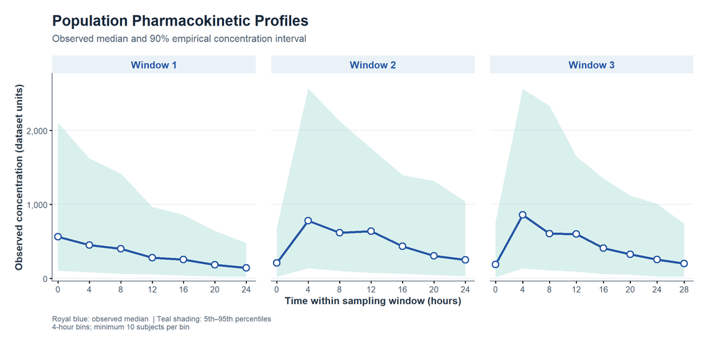

```r
# ==========================================================
# PUBLICATION-STYLE POPULATION PK VISUALIZATION
# ==========================================================

library(ggplot2)
library(scales)

# Professional scientific color palette
median_color <- "#2455A4"
interval_color <- "#79C9BE"

p_pk <- ggplot(
  population_window_summary,
  aes(x = Time_Bin)
) +

  # Empirical 90% concentration interval
  geom_ribbon(
    aes(ymin = P05, ymax = P95),
    fill = interval_color,
    alpha = 0.28
  ) +

  # Observed population median
  geom_line(
    aes(y = Median),
    color = median_color,
    linewidth = 1.4,
    lineend = "round"
  ) +

  # White-centered observation markers
  geom_point(
    aes(y = Median),
    shape = 21,
    size = 3,
    stroke = 1.2,
    fill = "white",
    color = median_color
  ) +

  # Three sampling windows
  facet_wrap(
    ~ Window,
    nrow = 1,
    scales = "free_x"
  ) +

  scale_x_continuous(
    breaks = seq(0, 28, by = 4),
    expand = expansion(mult = c(0.03, 0.05))
  ) +

  scale_y_continuous(
    labels = label_comma(),
    expand = expansion(mult = c(0.02, 0.08))
  ) +

  labs(
    title = "Population Pharmacokinetic Profiles",
    subtitle = "Observed median and 90% empirical concentration interval",
    x = "Time within sampling window (hours)",
    y = "Observed concentration (dataset units)",
    caption = paste(
      "Royal blue: observed median  |",
      "Teal shading: 5th–95th percentiles",
      "\n4-hour bins; minimum 10 subjects per bin"
    )
  ) +

  theme_classic(base_size = 13) +

  theme(
    plot.title = element_text(
      face = "bold",
      size = 18,
      color = "#18283B"
    ),

    plot.subtitle = element_text(
      size = 12,
      color = "#526273",
      margin = margin(b = 15)
    ),

    strip.background = element_rect(
      fill = "#EAF2F7",
      color = NA
    ),

    strip.text = element_text(
      face = "bold",
      size = 12,
      color = "#2455A4"
    ),

    axis.title = element_text(
      face = "bold",
      size = 12,
      color = "#263746"
    ),

    axis.text = element_text(
      size = 10,
      color = "#465666"
    ),

    axis.line = element_line(
      color = "#465666",
      linewidth = 0.5
    ),

    panel.grid.major.y = element_line(
      color = "#E8EDF2",
      linewidth = 0.4
    ),

    panel.grid.minor = element_blank(),

    panel.spacing = grid::unit(1.3, "lines"),

    plot.caption = element_text(
      size = 9,
      color = "#526273",
      hjust = 0,
      margin = margin(t = 12)
    ),

    plot.margin = margin(18, 20, 15, 18)
  )

# Display figure
print(p_pk)
```

```r
# Save high-resolution figure
dir.create(
  "results/figures",
  recursive = TRUE,
  showWarnings = FALSE
)

ggsave(
  filename = "results/figures/Population_PK_Three_Panels.png",
  plot = p_pk,
  width = 12,
  height = 5.8,
  dpi = 300,
  bg = "white"
)
```

```r
# Simulation 1: Observed PK Concentration-Time Profiles

#This analysis visualizes the observed pharmacokinetic
#concentration-time profiles for the first 10 subjects
#in the dataset.

#Only valid observation records were included
# Select valid observation records
pk_obs <- pk_data %>%
  filter(
    EVID == 0,
    MDV == 0,
    DV > 0,
    TIME >= 0
  )

# Select the first 10 subjects
subjects <- sort(unique(pk_obs$ID))[1:10]

# Prepare data for visualization
pk_10 <- pk_obs %>%
  filter(ID %in% subjects) %>%
  arrange(ID, TIME) %>%
  mutate(ID = factor(ID, levels = subjects))

# Verify results
print(subjects)
```

```
##  [1]  1  2  3  4  5  6  7  8  9 10
```

```r
dim(pk_10)
```

```
## [1] 580  14
```

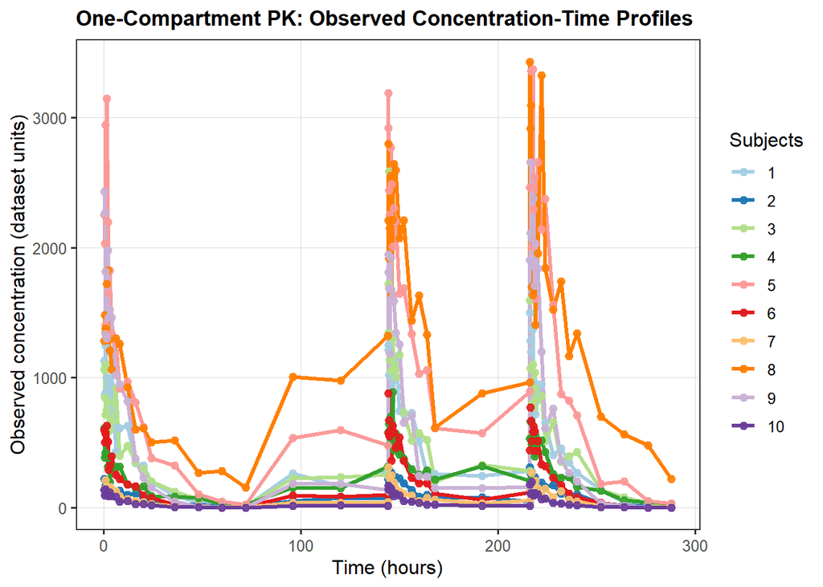

```r
# =====================================================
# SIMULATION 1: OBSERVED PK CONCENTRATION-TIME PROFILES
# =====================================================

library(dplyr)
library(ggplot2)

# 1. Select valid observation records
pk_obs <- pk_data %>%
  filter(
    EVID == 0,
    MDV == 0,
    DV > 0,
    TIME >= 0
  )

# 2. Select the first 10 subjects
subjects <- sort(unique(pk_obs$ID))[1:10]

# 3. Filter selected subjects
pk_10 <- pk_obs %>%
  filter(ID %in% subjects) %>%
  arrange(ID, TIME) %>%
  mutate(ID = factor(ID, levels = subjects))

# 4. Generate observed concentration-time profiles
p_sim1 <- ggplot(
  pk_10,
  aes(
    x = TIME,
    y = DV,
    color = ID,
    group = ID
  )
) +
  geom_line(
    linewidth = 1.2,
    alpha = 1
  ) +
  geom_point(
    size = 2,
    alpha = 0.9
  ) +
  scale_color_brewer(palette = "Paired") +
  labs(
    title = "One-Compartment PK: Observed Concentration-Time Profiles",
    x = "Time (hours)",
    y = "Observed concentration (dataset units)",
    color = "Subjects"
  ) +
  theme_bw(base_size = 12) +
  theme(
    plot.title = element_text(face = "bold", size = 13),
    legend.position = "right",
    panel.grid.major = element_line(
      color = "grey85",
      linewidth = 0.3
    ),
    panel.grid.minor = element_blank()
  )

# 5. Display figure
print(p_sim1)
```

```r
# 6. Save figure
dir.create(
  "results/figures",
  recursive = TRUE,
  showWarnings = FALSE
)

ggsave(
  filename = "results/figures/Observed_PK_Profiles.png",
  plot = p_sim1,
  width = 15,
  height = 6,
  dpi = 300,
  bg = "white"
)

# 7. Verify selected subjects
cat("Number of subjects:", length(subjects), "\n")
```

```
## Number of subjects: 10
```

# Monte Carlo Simulation of 10,000 Virtual Subjects

## Objective

To evaluate interindividual variability in drug exposure using a one-compartment intravenous bolus pharmacokinetic model and Monte Carlo simulation.

A virtual population of 10,000 subjects was generated by resampling individual clearance and volume of distribution parameters from the original simulated dataset.

Repeated-dose concentrations were predicted using superposition:

$$C_i(t) = \sum_{j:t_{ij}\leq t}
\frac{D_{ij}}{V_i}
\exp\left[-\frac{CL_i}{V_i}(t-t_{ij})\right]$$

where $D_{ij}$ is the administered dose, $t_{ij}$ is its administration time, and $CL_i$ and $V_i$ are the clearance and volume parameters for virtual subject $i$.

## Simulation Methodology

Individual parameter pairs and complete dosing histories were resampled together from the original subjects. The original relationship between clearance, volume, and dosing history was therefore preserved in the empirical resampling scheme.

A fixed random seed was used to ensure reproducibility.

## Interpretation

The Monte Carlo simulation predicts concentration–time profiles for 10,000 virtual subjects using a one-compartment repeated IV bolus model.

The median concentration profile represents the central tendency of simulated exposure, while the 5th–95th percentile interval represents variability in predicted concentrations across the virtual population.

The simulation propagates empirical variability in CL, V, and dosing histories from the original dataset. Because parameters are resampled from existing subjects rather than estimated using a new population model, this analysis represents an empirical, model-based simulation rather than a newly fitted nonlinear mixed-effects population PK model.

The resulting profiles can be used to investigate concentration variability and subsequently evaluate hypothetical exposure target attainment.

## Reproducibility

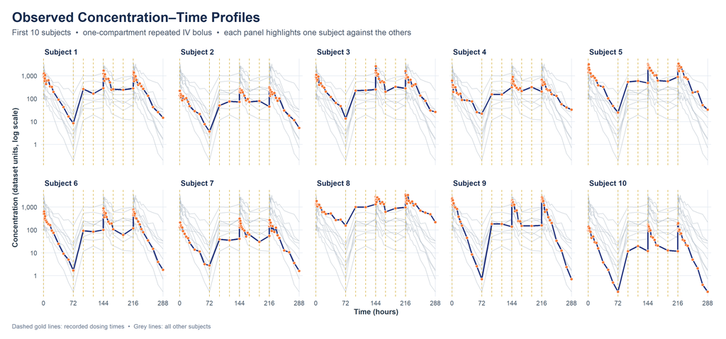

```r
# Simulation 1: Observed PK Concentration-Time Profiles

#This analysis visualizes the observed pharmacokinetic concentration-time profiles for the first 10 subjects in the dataset. Only valid observation records (`EVID == 0`, `MDV == 0`, `DV > 0`, `TIME >= 0`) are included. Concentrations are shown on a log scale so that both peaks and troughs are readable.


library(dplyr)
library(ggplot2)
library(scales)

# =====================================================
# SIMULATION 1: OBSERVED PK CONCENTRATION-TIME PROFILES
# =====================================================

# ---- Settings -------------------------------------------------
bg_color    <- "white"      # try "#CDEBFA" for sky blue
line_color  <- "#1E2F7A"    # highlighted subject
point_color <- "#F47735"
dose_color  <- "#C99700"
grey_color  <- "#B8C2CC"

# ---- 1. Data prep ---------------------------------------------
pk_obs <- pk_data %>%
  filter(EVID == 0, MDV == 0, DV > 0, TIME >= 0)

subjects <- sort(unique(pk_obs$ID))[1:10]

pk_10 <- pk_obs %>%
  filter(ID %in% subjects) %>%
  arrange(ID, TIME) %>%
  mutate(ID = factor(ID, levels = subjects))

dose_10 <- pk_data %>%
  filter(EVID == 1, AMT > 0, ID %in% subjects) %>%
  distinct(ID, TIME) %>%
  mutate(ID = factor(ID, levels = subjects))

pk_bg <- pk_10 %>% rename(ID_bg = ID)

# ---- 2. Shared theme ------------------------------------------
theme_pk <- theme_minimal(base_size = 13) +
  theme(
    plot.background   = element_rect(fill = bg_color, color = NA),
    panel.background  = element_rect(fill = bg_color, color = NA),
    plot.title.position   = "plot",
    plot.caption.position = "plot",
    plot.title    = element_text(face = "bold", size = 20, color = "#172B4D"),
    plot.subtitle = element_text(size = 12, color = "#475569", margin = margin(b = 12)),
    plot.caption  = element_text(size = 9, color = "#64748B", hjust = 0, margin = margin(t = 12)),
    axis.title    = element_text(face = "bold", size = 11, color = "#263746"),
    axis.text     = element_text(size = 9.5, color = "#465666"),
    panel.grid.major = element_line(color = "#E2E8F0", linewidth = 0.35),
    panel.grid.minor = element_blank(),
    strip.text    = element_text(face = "bold", size = 11, color = "#172B4D", hjust = 0),
    panel.spacing = unit(1.1, "lines"),
    plot.margin   = margin(18, 22, 14, 18)
  )

# ---- 3. Figure A: one panel per subject -----------------------
p_sim1 <- ggplot(pk_10, aes(TIME, DV)) +
  geom_line(data = pk_bg, aes(group = ID_bg),
            color = grey_color, linewidth = 0.35, alpha = 0.7) +
  geom_vline(data = dose_10, aes(xintercept = TIME),
             color = dose_color, linetype = "dashed", linewidth = 0.4, alpha = 0.8) +
  geom_line(aes(group = ID), color = line_color, linewidth = 0.9) +
  geom_point(shape = 21, fill = point_color, color = "white",
             size = 1.9, stroke = 0.4) +
  facet_wrap(~ ID, ncol = 5,
             labeller = labeller(ID = function(x) paste("Subject", x))) +
  scale_x_continuous(breaks = seq(0, 288, 72),
                     expand = expansion(mult = c(0.02, 0.03))) +
  scale_y_log10(labels = label_comma(), breaks = log_breaks(n = 5)) +
  labs(
    title    = "Observed Concentration–Time Profiles",
    subtitle = "First 10 subjects  •  one-compartment repeated IV bolus  •  each panel highlights one subject against the others",
    x = "Time (hours)",
    y = "Concentration (dataset units, log scale)",
    caption  = "Dashed gold lines: recorded dosing times  •  Grey lines: all other subjects"
  ) +
  theme_pk

# ---- 4. Figure B: single-panel overview -----------------------
p_sim1_overview <- ggplot(pk_10, aes(TIME, DV, color = ID, group = ID)) +
  geom_vline(data = dose_10 %>% distinct(TIME), aes(xintercept = TIME),
             inherit.aes = FALSE, color = dose_color,
             linetype = "dashed", linewidth = 0.4, alpha = 0.7) +
  geom_line(linewidth = 0.7, alpha = 0.85) +
  geom_point(size = 1.4, alpha = 0.9) +
  scale_color_viridis_d(option = "turbo", end = 0.92, name = "Subject") +
  scale_x_continuous(breaks = seq(0, 288, 24),
                     expand = expansion(mult = c(0.01, 0.02))) +
  scale_y_log10(labels = label_comma(), breaks = log_breaks(n = 6)) +
  labs(
    title    = "Observed Concentration–Time Profiles",
    subtitle = "First 10 subjects  •  log-scaled concentration",
    x = "Time (hours)",
    y = "Concentration (dataset units, log scale)",
    caption  = "Dashed gold lines: recorded dosing times"
  ) +
  guides(color = guide_legend(nrow = 1,
                              override.aes = list(linewidth = 1.5, size = 2.5))) +
  theme_pk +
  theme(legend.position = "top", legend.justification = "left")

# ---- 5. Display and save --------------------------------------
print(p_sim1)
```

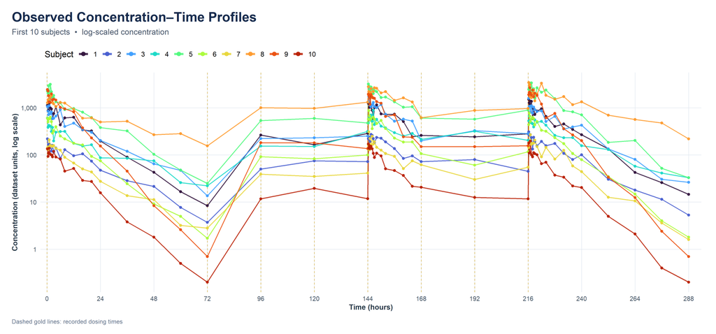

```r
print(p_sim1_overview)
```

```r
dir.create("results/figures", recursive = TRUE, showWarnings = FALSE)

ggsave("results/figures/Observed_PK_Profiles_Panels.png", p_sim1,
       width = 15, height = 7, dpi = 300, bg = bg_color)
ggsave("results/figures/Observed_PK_Profiles_Overview.png", p_sim1_overview,
       width = 12, height = 6.5, dpi = 300, bg = bg_color)

cat("Number of subjects:", length(subjects), "\n")
```

```
## Number of subjects: 10
```

```r
# Recover the simulation summary from saved results
summary_file <- "results/tables/Monte_Carlo_Concentration_Summary.csv"

if (file.exists(summary_file)) {

  simulation_summary <- read.csv(summary_file)

} else if (
  exists("simulation_matrix") &&
  exists("simulation_time")
) {

  simulation_summary <- data.frame(
    TIME = simulation_time,
    Median = apply(simulation_matrix, 2, median),
    P05 = apply(simulation_matrix, 2, quantile, probs = 0.05),
    P95 = apply(simulation_matrix, 2, quantile, probs = 0.95)
  )

} else {

  stop(
    "Monte Carlo results are missing. ",
    "Run the complete 10,000-subject simulation ",
    "before creating the enhanced figure."
  )
}

head(simulation_summary)
```

```
##   TIME   Median       P05      P95
## 1    0 585.3659 111.91942 2243.410
## 2    1 566.7095 106.54150 2070.343
## 3    2 523.6727 101.42200 1927.415
## 4    3 504.1220  96.27337 1794.354
## 5    4 485.3012  89.35559 1670.480
## 6    5 464.9555  81.65616 1495.612
```

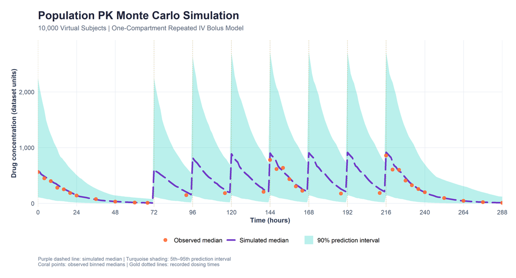

```r
library(dplyr)
library(ggplot2)
library(scales)

## Enhanced Monte Carlo Simulation Visualization

#This visualization compares observed pharmacokinetic concentrations with simulated population concentrations from 10,000 #virtual subjects using a one-compartment repeated intravenous bolus model.


# ============================================================
# ENHANCED MONTE CARLO SIMULATION VISUALIZATION
# 10,000 VIRTUAL SUBJECTS
# ============================================================

# 1. Define professional color palette
median_color <- "#7038C6"
interval_color <- "#00C9B7"
observed_color <- "#FF6B35"
dose_color <- "#D4A017"

# 2. Prepare observed concentrations
# Summarize observations in 4-hour bins
observed_summary <- pk_data %>%
  filter(
    EVID == 0,
    MDV == 0,
    is.finite(DV),
    DV > 0,
    is.finite(TIME),
    TIME >= 0
  ) %>%
  mutate(
    Time_Bin = floor(TIME / 4) * 4
  ) %>%
  group_by(ID, Time_Bin) %>%
  summarise(
    DV = median(DV),
    .groups = "drop"
  ) %>%
  group_by(Time_Bin) %>%
  summarise(
    N = n(),
    Observed_Median = median(DV),
    .groups = "drop"
  ) %>%
  filter(N >= 10)

# 3. Identify actual dose administration times
dose_times <- pk_data %>%
  filter(
    EVID == 1,
    AMT > 0,
    is.finite(TIME)
  ) %>%
  distinct(TIME) %>%
  arrange(TIME)

# 4. Generate enhanced Monte Carlo plot
p_mc_beautiful <- ggplot() +

  # 90% simulated population prediction interval
  geom_ribbon(
    data = simulation_summary,
    aes(
      x = TIME,
      ymin = P05,
      ymax = P95,
      fill = "90% prediction interval"
    ),
    alpha = 0.27
  ) +

  # Dose administration indicators
  geom_vline(
    data = dose_times,
    aes(xintercept = TIME),
    color = dose_color,
    linetype = "dotted",
    linewidth = 0.55,
    alpha = 0.60
  ) +

  # Dashed simulated median concentration
  geom_line(
    data = simulation_summary,
    aes(
      x = TIME,
      y = Median,
      color = "Simulated median"
    ),
    linewidth = 1.35,
    linetype = "longdash",
    lineend = "round"
  ) +

  # Observed median concentrations
  geom_point(
    data = observed_summary,
    aes(
      x = Time_Bin,
      y = Observed_Median,
      color = "Observed median"
    ),
    shape = 21,
    fill = observed_color,
    stroke = 0.7,
    size = 2.5,
    alpha = 0.90
  ) +

  # Manual scientific color palette
  scale_color_manual(
    name = NULL,
    values = c(
      "Simulated median" = median_color,
      "Observed median" = observed_color
    )
  ) +

  scale_fill_manual(
    name = NULL,
    values = c(
      "90% prediction interval" = interval_color
    )
  ) +

  # X-axis
  scale_x_continuous(
    breaks = seq(0, 288, by = 24),
    limits = c(0, 288),
    expand = c(0, 0)
  ) +

  # Y-axis
  scale_y_continuous(
    labels = label_comma(),
    expand = expansion(mult = c(0.02, 0.08))
  ) +

  # Labels
  labs(
    title = "Population PK Monte Carlo Simulation",
    subtitle = paste(
      "10,000 Virtual Subjects |",
      "One-Compartment Repeated IV Bolus Model"
    ),
    x = "Time (hours)",
    y = "Drug concentration (dataset units)",
    caption = paste(
      "Purple dashed line: simulated median |",
      "Turquoise shading: 5th–95th prediction interval",
      "\nCoral points: observed binned medians |",
      "Gold dotted lines: recorded dosing times"
    )
  ) +

  # Professional white background
  theme_minimal(base_size = 14) +

  theme(
    plot.title = element_text(
      face = "bold",
      size = 20,
      color = "#20243A"
    ),

    plot.subtitle = element_text(
      size = 12,
      color = "#596579",
      margin = margin(b = 16)
    ),

    axis.title = element_text(
      face = "bold",
      size = 12,
      color = "#26334D"
    ),

    axis.text = element_text(
      size = 11,
      color = "#46556A"
    ),

    panel.grid.major = element_line(
      color = "#E7EBF2",
      linewidth = 0.35
    ),

    panel.grid.minor = element_blank(),

    legend.position = "bottom",

    legend.text = element_text(
      size = 11
    ),

    legend.box = "horizontal",

    plot.caption = element_text(
      size = 9,
      color = "#64748B",
      hjust = 0,
      margin = margin(t = 15)
    ),

    plot.margin = margin(20, 25, 20, 20)
  ) +

  guides(
    color = guide_legend(order = 1),
    fill = guide_legend(order = 2)
  )

# 5. Display figure
print(p_mc_beautiful)
```

```r
# 6. Save publication-quality figure
dir.create(
  "results/figures",
  recursive = TRUE,
  showWarnings = FALSE
)

ggsave(
  filename = "results/figures/Monte_Carlo_10000_Enhanced.png",
  plot = p_mc_beautiful,
  width = 13,
  height = 7,
  dpi = 300,
  bg = "white"
)

# 7. Save vector-format figure
ggsave(
  filename = "results/figures/Monte_Carlo_10000_Enhanced.pdf",
  plot = p_mc_beautiful,
  width = 13,
  height = 7,
  bg = "white"
)

cat(
  "\nEnhanced Monte Carlo figure saved successfully.\n"
)
```

```
##
## Enhanced Monte Carlo figure saved successfully.
```

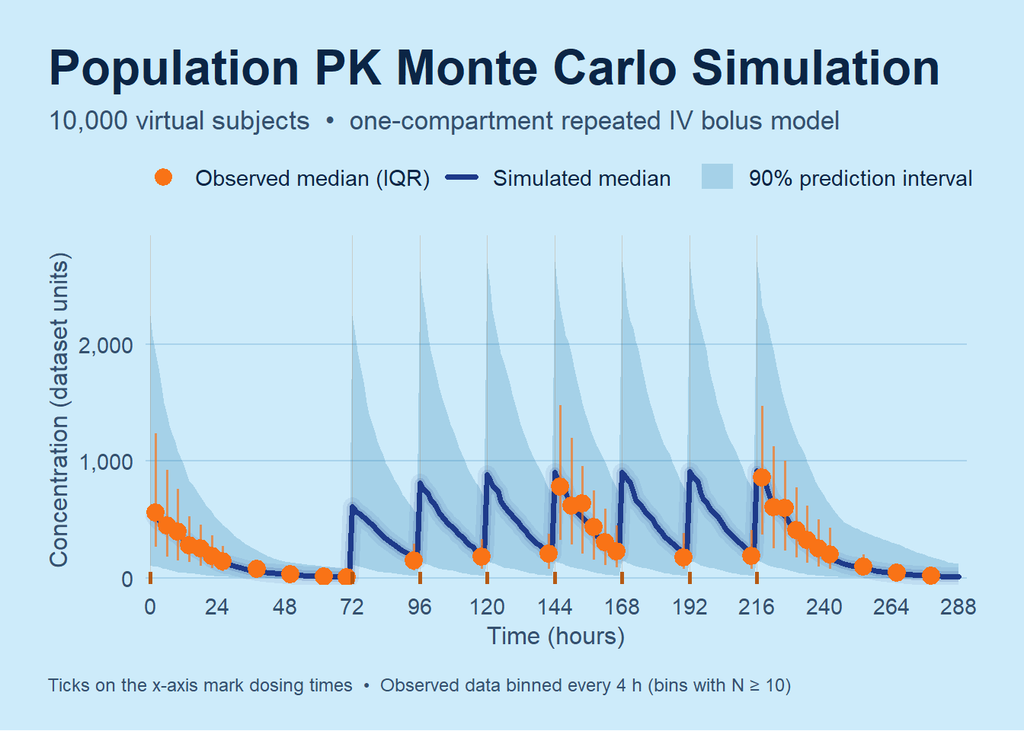

```r
library(dplyr)
library(ggplot2)
library(scales)

# ------------------------------------------------------------
# 0. Optional: nicer font (falls back silently if unavailable)
# ------------------------------------------------------------
font_family <- "sans"
try({
  sysfonts::font_add_google("Inter", "Inter")
  showtext::showtext_auto()
  font_family <- "Inter"
}, silent = TRUE)

# ------------------------------------------------------------
# 1. Data prep
# ------------------------------------------------------------
bin_width <- 4

observed_summary <- pk_data %>%
  filter(EVID == 0, MDV == 0, is.finite(DV), DV > 0,
         is.finite(TIME), TIME >= 0) %>%
  mutate(Time_Bin = floor(TIME / bin_width) * bin_width) %>%
  group_by(ID, Time_Bin) %>%
  summarise(DV = median(DV), .groups = "drop") %>%
  group_by(Time_Bin) %>%
  summarise(
    N               = n(),
    Observed_Median = median(DV),
    Obs_Q25         = quantile(DV, 0.25),
    Obs_Q75         = quantile(DV, 0.75),
    .groups = "drop"
  ) %>%
  filter(N >= 10) %>%
  mutate(Time_Mid = Time_Bin + bin_width / 2)

dose_times <- pk_data %>%
  filter(EVID == 1, AMT > 0, is.finite(TIME)) %>%
  distinct(TIME) %>%
  arrange(TIME)

# The 50% band is drawn only if simulation_summary has P25 and P75
has_iqr <- all(c("P25", "P75") %in% names(simulation_summary))

# ------------------------------------------------------------
# 2. Sky-blue palette
# ------------------------------------------------------------
bg_color <- "#CDEBFA"   # sky-blue background (change here to adjust)

pal <- list(
  bg      = bg_color,
  text    = "#0B2545",
  subtext = "#34506E",
  grid    = "#A9D3EC",
  median  = "#1E3A8A",   # deep navy
  band90  = "#0369A1",   # strong blue
  band50  = "#075985",
  obs     = "#F97316",   # orange
  dose    = "#B45309",
  a90     = 0.20,
  a50     = 0.30
)

# ------------------------------------------------------------
# 3. Plot
# ------------------------------------------------------------
make_mc_plot <- function(log_y = FALSE) {

  ggplot() +
    # 90% prediction interval
    geom_ribbon(data = simulation_summary,
                aes(TIME, ymin = P05, ymax = P95, fill = "90% prediction interval"),
                alpha = pal$a90) +
    # 50% prediction interval (optional)
    { if (has_iqr)
        geom_ribbon(data = simulation_summary,
                    aes(TIME, ymin = P25, ymax = P75, fill = "50% prediction interval"),
                    alpha = pal$a50) } +
    # faint dose guide lines
    geom_vline(data = dose_times, aes(xintercept = TIME),
               color = pal$dose, linewidth = 0.3, alpha = 0.20) +
    # soft glow under the median
    geom_line(data = simulation_summary, aes(TIME, Median),
              color = pal$median, linewidth = 4.5, alpha = 0.08, show.legend = FALSE) +
    geom_line(data = simulation_summary, aes(TIME, Median),
              color = pal$median, linewidth = 2.6, alpha = 0.15, show.legend = FALSE) +
    # median line
    geom_line(data = simulation_summary,
              aes(TIME, Median, color = "Simulated median"),
              linewidth = 1.3, lineend = "round") +
    # observed IQR whiskers
    geom_linerange(data = observed_summary,
                   aes(x = Time_Mid, ymin = Obs_Q25, ymax = Obs_Q75),
                   color = pal$obs, linewidth = 0.6, alpha = 0.70) +
    # observed medians
    geom_point(data = observed_summary,
               aes(Time_Mid, Observed_Median, color = "Observed median (IQR)"),
               shape = 21, fill = pal$obs, stroke = 1, size = 3.2) +
    # dose ticks on the x-axis
    geom_rug(data = dose_times, aes(x = TIME), inherit.aes = FALSE,
             sides = "b", color = pal$dose, linewidth = 0.9,
             length = unit(0.035, "npc"), alpha = 0.95) +

    scale_color_manual(NULL, values = c(
      "Simulated median"      = pal$median,
      "Observed median (IQR)" = pal$obs)) +
    scale_fill_manual(NULL,
      values = c("90% prediction interval" = pal$band90,
                 "50% prediction interval" = pal$band50),
      breaks = c("90% prediction interval", "50% prediction interval")) +

    scale_x_continuous(breaks = seq(0, 288, 24), limits = c(0, 288),
                       expand = expansion(mult = c(0.005, 0.01))) +
    { if (log_y)
        scale_y_log10(labels = label_comma(), expand = expansion(mult = c(0.02, 0.08)))
      else
        scale_y_continuous(labels = label_comma(), expand = expansion(mult = c(0.02, 0.08))) } +

    labs(
      title    = "Population PK Monte Carlo Simulation",
      subtitle = "10,000 virtual subjects  •  one-compartment repeated IV bolus model",
      x = "Time (hours)", y = "Concentration (dataset units)",
      caption  = "Ticks on the x-axis mark dosing times  •  Observed data binned every 4 h (bins with N ≥ 10)"
    ) +

    theme_minimal(base_size = 14, base_family = font_family) +
    theme(
      plot.background  = element_rect(fill = pal$bg, color = NA),
      panel.background = element_rect(fill = pal$bg, color = NA),
      text             = element_text(color = pal$text),
      plot.title.position = "plot",
      plot.title    = element_text(face = "bold", size = 24, color = pal$text),
      plot.subtitle = element_text(size = 13, color = pal$subtext, margin = margin(b = 14)),
      axis.title    = element_text(size = 12, color = pal$subtext),
      axis.text     = element_text(size = 11, color = pal$subtext),
      panel.grid.major.y = element_line(color = pal$grid, linewidth = 0.4),
      panel.grid.major.x = element_blank(),
      panel.grid.minor   = element_blank(),
      legend.position      = "top",
      legend.justification = "left",
      legend.text   = element_text(size = 11, color = pal$text),
      legend.key.height = unit(0.5, "cm"),
      legend.margin = margin(0, 0, 8, 0),
      plot.caption  = element_text(size = 9, color = pal$subtext, hjust = 0, margin = margin(t = 14)),
      plot.caption.position = "plot",
      plot.margin   = margin(24, 28, 18, 24)
    ) +
    guides(
      color = guide_legend(order = 1, override.aes = list(linewidth = 1.3, size = 3)),
      fill  = guide_legend(order = 2)
    )
}

# ------------------------------------------------------------
# 4. Build, preview, and save
# ------------------------------------------------------------
p_skyblue <- make_mc_plot()
print(p_skyblue)
```

```r
dir.create("results/figures", recursive = TRUE, showWarnings = FALSE)

ggsave("results/figures/Monte_Carlo_10000_skyblue.png", p_skyblue,
       width = 12, height = 6.75, dpi = 200, bg = bg_color)
ggsave("results/figures/Monte_Carlo_10000_skyblue.pdf", p_skyblue,
       width = 12, height = 6.75, device = cairo_pdf, bg = bg_color)

cat("\nSky-blue Monte Carlo figure saved successfully.\n")
```

```
##
## Sky-blue Monte Carlo figure saved successfully.
```

## Monte Carlo Model Validation

This figure compares observed pharmacokinetic concentrations (binned medians with IQR) with simulated population concentrations from 10,000 virtual subjects using a one-compartment repeated intravenous bolus model. Observed medians that fall outside the simulated 90% prediction interval are highlighted in red.

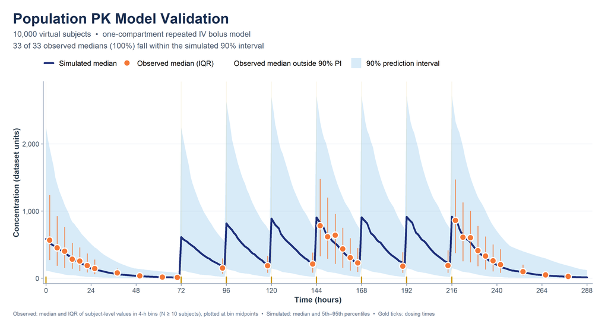

```r
library(dplyr)
library(ggplot2)
library(scales)

# ============================================================
# MONTE CARLO VALIDATION FIGURE (10,000 VIRTUAL SUBJECTS)
# ============================================================

# ---- Settings -------------------------------------------------
bg_color   <- "white"      # try "#CDEBFA" for the sky-blue version
bin_width  <- 4

sim_color  <- "#1E2F7A"    # simulated median
band_color <- "#4FA3E0"    # prediction bands
obs_color  <- "#F47735"    # observed (inside interval)
out_color  <- "#D62839"    # observed (outside interval)
dose_color <- "#C99700"

# ---- 1. Observed summary -------------------------------------
observed_summary <- pk_data %>%
  filter(EVID == 0, MDV == 0, is.finite(DV), DV > 0,
         is.finite(TIME), TIME >= 0) %>%
  mutate(Time_Bin = floor(TIME / bin_width) * bin_width) %>%
  group_by(ID, Time_Bin) %>%
  summarise(DV = median(DV), .groups = "drop") %>%
  group_by(Time_Bin) %>%
  summarise(N = n(),
            Median = median(DV),
            Q1 = quantile(DV, 0.25),
            Q3 = quantile(DV, 0.75),
            .groups = "drop") %>%
  filter(N >= 10) %>%
  mutate(Time_Mid = Time_Bin + bin_width / 2)

# ---- 2. Coverage check vs simulated 90% interval -------------
ss <- simulation_summary %>% arrange(TIME)

observed_summary <- observed_summary %>%
  mutate(
    Sim_P05 = approx(ss$TIME, ss$P05, xout = Time_Mid, rule = 2)$y,
    Sim_P95 = approx(ss$TIME, ss$P95, xout = Time_Mid, rule = 2)$y,
    Inside  = Median >= Sim_P05 & Median <= Sim_P95,
    Status  = ifelse(Inside, "Observed median (IQR)",
                             "Observed median outside 90% PI")
  )

n_in  <- sum(observed_summary$Inside)
n_tot <- nrow(observed_summary)
coverage_label <- sprintf("%d of %d observed medians (%.0f%%) fall within the simulated 90%% interval",
                          n_in, n_tot, 100 * n_in / n_tot)

# ---- 3. Dose times and optional 50% band ---------------------
dose_times <- pk_data %>%
  filter(EVID == 1, AMT > 0, is.finite(TIME)) %>%
  distinct(TIME) %>%
  arrange(TIME)

has_iqr <- all(c("P25", "P75") %in% names(simulation_summary))

# ---- 4. Plot --------------------------------------------------
col_values <- c("Simulated median"                = sim_color,
                "Observed median (IQR)"           = obs_color,
                "Observed median outside 90% PI"  = out_color)

p_mc_final <- ggplot() +

  geom_ribbon(data = simulation_summary,
              aes(TIME, ymin = P05, ymax = P95, fill = "90% prediction interval"),
              alpha = 0.22) +

  { if (has_iqr)
      geom_ribbon(data = simulation_summary,
                  aes(TIME, ymin = P25, ymax = P75, fill = "50% prediction interval"),
                  alpha = 0.32) } +

  geom_vline(data = dose_times, aes(xintercept = TIME),
             color = dose_color, linewidth = 0.3, alpha = 0.18) +

  geom_line(data = simulation_summary,
            aes(TIME, Median, color = "Simulated median"),
            linewidth = 1.4, lineend = "round") +

  # observed IQR whiskers
  geom_linerange(data = observed_summary,
                 aes(x = Time_Mid, ymin = Q1, ymax = Q3),
                 color = obs_color, linewidth = 0.7, alpha = 0.75) +

  # white halo so points stay readable over bands and lines
  geom_point(data = observed_summary,
             aes(Time_Mid, Median),
             shape = 16, size = 5.2, color = "white") +

  geom_point(data = observed_summary,
             aes(Time_Mid, Median, color = Status),
             shape = 16, size = 3.6) +

  geom_rug(data = dose_times, aes(x = TIME), inherit.aes = FALSE,
           sides = "b", color = dose_color, linewidth = 0.9,
           length = unit(0.035, "npc")) +

  scale_color_manual(NULL, values = col_values, limits = names(col_values)) +
  scale_fill_manual(NULL,
                    values = c("90% prediction interval" = band_color,
                               "50% prediction interval" = band_color),
                    breaks = c("90% prediction interval", "50% prediction interval")) +

  scale_x_continuous(breaks = seq(0, 288, 24), limits = c(0, 288),
                     expand = expansion(mult = c(0.005, 0.01))) +
  scale_y_continuous(labels = label_comma(),
                     expand = expansion(mult = c(0.03, 0.08))) +

  labs(
    title    = "Population PK Model Validation",
    subtitle = paste0("10,000 virtual subjects  •  one-compartment repeated IV bolus model\n",
                      coverage_label),
    x = "Time (hours)",
    y = "Concentration (dataset units)",
    caption = paste0("Observed: median and IQR of subject-level values in ", bin_width,
                     "-h bins (N ≥ 10 subjects), plotted at bin midpoints  •  ",
                     "Simulated: median and 5th–95th percentiles  •  Gold ticks: dosing times")
  ) +

  theme_classic(base_size = 14) +
  theme(
    plot.background  = element_rect(fill = bg_color, color = NA),
    panel.background = element_rect(fill = bg_color, color = NA),
    plot.title.position   = "plot",
    plot.caption.position = "plot",
    plot.title    = element_text(face = "bold", size = 22, color = "#172B4D"),
    plot.subtitle = element_text(size = 12, color = "#475569", lineheight = 1.25,
                                 margin = margin(b = 12)),
    axis.title    = element_text(face = "bold", size = 12, color = "#263746"),
    axis.text     = element_text(size = 10.5, color = "#465666"),
    axis.line     = element_line(color = "#94A3B8", linewidth = 0.5),
    axis.ticks    = element_line(color = "#94A3B8"),
    panel.grid.major.y = element_line(color = "#E2E8F0", linewidth = 0.4),
    panel.grid.minor   = element_blank(),
    legend.position      = "top",
    legend.justification = "left",
    legend.text   = element_text(size = 11),
    legend.margin = margin(0, 0, 6, 0),
    plot.caption  = element_text(size = 8.5, color = "#64748B", hjust = 0,
                                 margin = margin(t = 12)),
    plot.margin   = margin(20, 24, 16, 20)
  ) +
  guides(
    color = guide_legend(
      order = 1,
      override.aes = list(linetype = c("solid", "blank", "blank"),
                          shape    = c(NA, 16, 16),
                          linewidth = c(1.4, 0, 0),
                          size      = c(0, 3.6, 3.6))
    ),
    fill = guide_legend(order = 2)
  )

# ---- 5. Display and save -------------------------------------
print(p_mc_final)
```

```r
dir.create("results/figures", recursive = TRUE, showWarnings = FALSE)

ggsave("results/figures/Monte_Carlo_10000_Validation.png", p_mc_final,
       width = 13, height = 7, dpi = 300, bg = bg_color)
ggsave("results/figures/Monte_Carlo_10000_Validation.pdf", p_mc_final,
       width = 13, height = 7, device = cairo_pdf, bg = bg_color)

cat("\n", coverage_label, "\n", sep = "")
```

```
##
## 33 of 33 observed medians (100%) fall within the simulated 90% interval
```